# [STAT 4400] Exam-1

Michael Ghattas

2/22/2022

# Part 1:

### (1)

True

### (2)

False

### (3)

True

### (4)

True

### (5)

False

### (6)

True

### (7)

True

### (8)

True

### (9)

True

### (10)

False

### (11)

True

### (12)

False

### (13)

False

### (14)

True

### (15)

False

### (16)

True

### (17)

True (IF by reflects we mean cause! As discussed with Bhawneet.)

### (18)

True

### (19)

False

### (20)

False (Correlated Explanatory Variables: If there are very many variables, it is likely that they will be highly correlated, meaning that some variables or sets of variables are measuring similar things. As discussed with Bhawneet.)

# Part 2:

### Problem - 1

```r
library(ggplot2)
head(msleep)
```

```
## # A tibble: 6 × 11
##   name    genus vore  order conservation sleep_total sleep_rem sleep_cycle awake
##   <chr>   <chr> <chr> <chr> <chr>              <dbl>     <dbl>       <dbl> <dbl>
## 1 Cheetah Acin… carni Carn… lc                  12.1      NA        NA      11.9
## 2 Owl mo… Aotus omni  Prim… <NA>                17         1.8      NA       7
## 3 Mounta… Aplo… herbi Rode… nt                  14.4       2.4      NA       9.6
## 4 Greate… Blar… omni  Sori… lc                  14.9       2.3       0.133   9.1
## 5 Cow     Bos   herbi Arti… domesticated         4         0.7       0.667  20
## 6 Three-… Brad… herbi Pilo… <NA>                14.4       2.2       0.767   9.6
## # … with 2 more variables: brainwt <dbl>, bodywt <dbl>
```

##### (1)

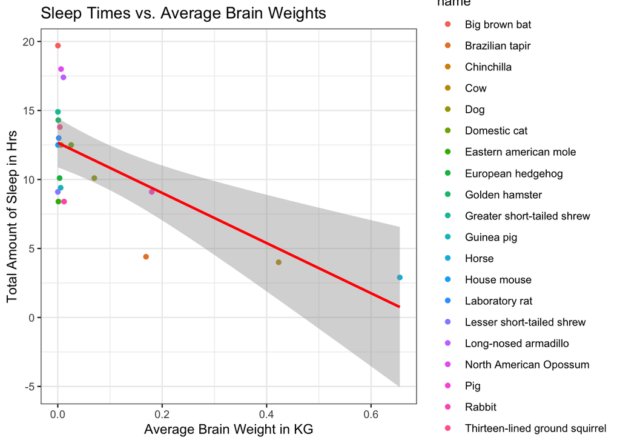

```r
df <- na.omit(msleep)
lmod = lm(sleep_total ~ brainwt, data = df)

ggplot(df, aes(brainwt, sleep_total, color = name)) +
  geom_point() +
  geom_smooth(method = lm, color = "red") +
  theme_bw() + xlab("Average Brain Weight in KG") +   ylab("Total Amount of Sleep in Hrs") +
  ggtitle("Sleep Times vs. Average Brain Weights")
```

##### (2)

```r
lmod = lm(sleep_total ~ awake + + bodywt + awake:bodywt + sleep_cycle, data = df)
summary(lmod)
```

```
##
## Call:
## lm(formula = sleep_total ~ awake + +bodywt + awake:bodywt + sleep_cycle,
##     data = df)
##
## Residuals:
##        Min         1Q     Median         3Q        Max
## -2.356e-15 -4.496e-16  1.575e-16  5.642e-16  1.660e-15
##
## Coefficients:
##                Estimate Std. Error    t value Pr(>|t|)
## (Intercept)   2.400e+01  8.801e-16  2.727e+16  < 2e-16 ***
## awake        -1.000e+00  7.642e-17 -1.309e+16  < 2e-16 ***
## bodywt       -1.090e-16  3.313e-17 -3.289e+00  0.00497 **
## sleep_cycle   5.005e-15  1.652e-15  3.029e+00  0.00846 **
## awake:bodywt  4.777e-18  1.608e-18  2.970e+00  0.00953 **
## ---
## Signif. codes:  0 '***' 0.001 '**' 0.01 '*' 0.05 '.' 0.1 ' ' 1
##
## Residual standard error: 1.046e-15 on 15 degrees of freedom
## Multiple R-squared:      1,  Adjusted R-squared:      1
## F-statistic: 8.968e+31 on 4 and 15 DF,  p-value: < 2.2e-16
```

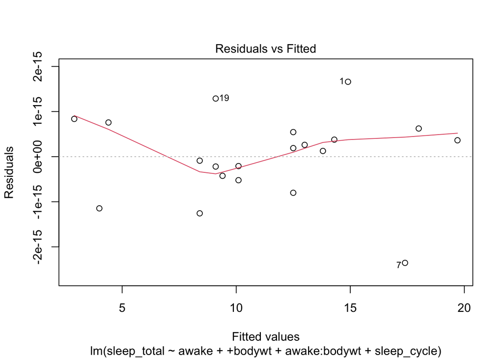

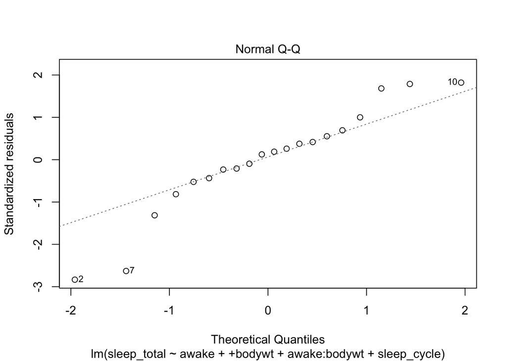

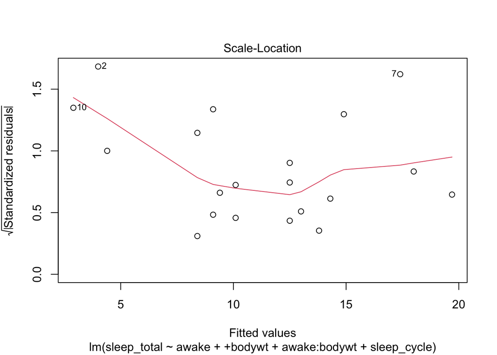

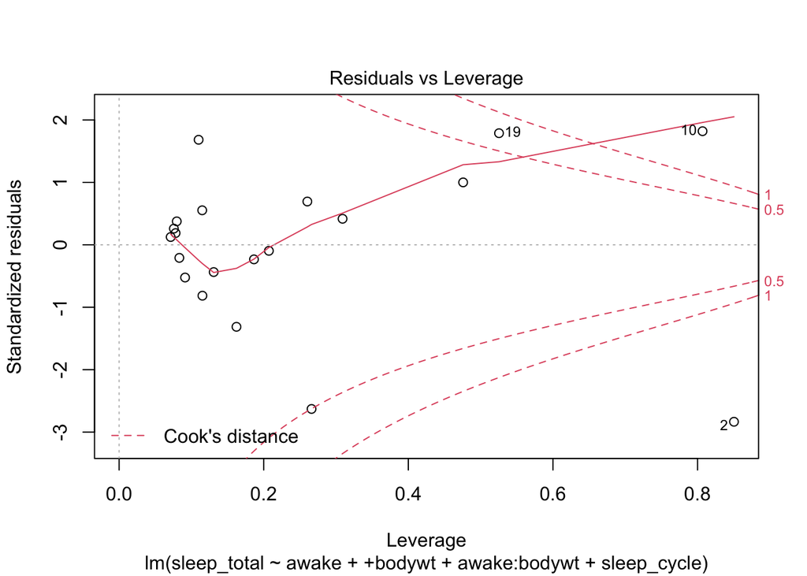

```r
plot(lmod)
```

##### (3)

```r
df$sleep_ratio <- (df$sleep_total / 24)
lmod = lm(sleep_total ~ sleep_ratio, data = df)
coef(lmod)
```

```
##   (Intercept)   sleep_ratio
## -7.944109e-15  2.400000e+01
```

```r
logitSR = (1 / (1 + exp(-1 * (-7.944109e-15 + (2.400e+01 * df$sleep_ratio))))); logitSR
```

```
##  [1] 0.9999997 0.9820138 0.9999589 0.9999173 0.9999963 0.9998883 1.0000000
##  [8] 1.0000000 1.0000000 0.9478464 0.9999589 0.9999963 0.9999994 0.9999963
## [15] 0.9997752 0.9999977 0.9997752 0.9999990 0.9998883 0.9878716
```

```r
lmod = lm(logitSR ~ log(brainwt), data = df)
summary(lmod)
```

```
##
## Call:
## lm(formula = logitSR ~ log(brainwt), data = df)
##
## Residuals:
##       Min        1Q    Median        3Q       Max
## -0.034601 -0.002356  0.001764  0.004298  0.013635
##
## Coefficients:
##                Estimate Std. Error t value Pr(>|t|)
## (Intercept)   0.9812003  0.0051040 192.243  < 2e-16 ***
## log(brainwt) -0.0029465  0.0009222  -3.195  0.00502 **
## ---
## Signif. codes:  0 '***' 0.001 '**' 0.01 '*' 0.05 '.' 0.1 ' ' 1
##
## Residual standard error: 0.01004 on 18 degrees of freedom
## Multiple R-squared:  0.3619, Adjusted R-squared:  0.3264
## F-statistic: 10.21 on 1 and 18 DF,  p-value: 0.005018
```

Interpreting the results of our coefficients, we can see a negative correlation between the brain weight of the animal and the amount of sleep. For every additional KG of weight, there is a decrease of approximately 0.3% of sleep time needed per 24 hours.

```r
df$sleep_ratio <- (df$sleep_ratio * 24)
lmod = lm(sleep_total ~ sleep_ratio, data = df)
coef(lmod)
```

```
##  (Intercept)  sleep_ratio
## 3.177644e-15 1.000000e+00
```

```r
logitSR = (1 / (1 + exp(-1 * (3.177644e-15 + (1.000000e+00 * df$sleep_ratio))))); logitSR
```

```
##  [1] 0.9999997 0.9820138 0.9999589 0.9999173 0.9999963 0.9998883 1.0000000
##  [8] 1.0000000 1.0000000 0.9478464 0.9999589 0.9999963 0.9999994 0.9999963
## [15] 0.9997752 0.9999977 0.9997752 0.9999990 0.9998883 0.9878716
```

```r
lmod = lm(logitSR ~ log(brainwt), data = df)
summary(lmod)
```

```
##
## Call:
## lm(formula = logitSR ~ log(brainwt), data = df)
##
## Residuals:
##       Min        1Q    Median        3Q       Max
## -0.034601 -0.002356  0.001764  0.004298  0.013635
##
## Coefficients:
##                Estimate Std. Error t value Pr(>|t|)
## (Intercept)   0.9812003  0.0051040 192.243  < 2e-16 ***
## log(brainwt) -0.0029465  0.0009222  -3.195  0.00502 **
## ---
## Signif. codes:  0 '***' 0.001 '**' 0.01 '*' 0.05 '.' 0.1 ' ' 1
##
## Residual standard error: 0.01004 on 18 degrees of freedom
## Multiple R-squared:  0.3619, Adjusted R-squared:  0.3264
## F-statistic: 10.21 on 1 and 18 DF,  p-value: 0.005018
```

We can see that returning from 24 hors to hours do not change our results and mantain the sleep time between 0 and 24, though never reaching 0 or 24.

##### (4)

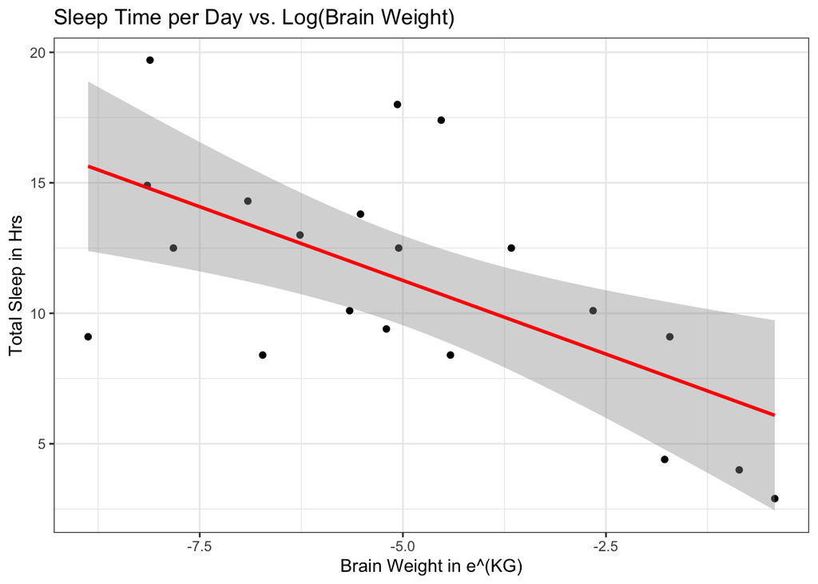

```r
ggplot(df, aes(log(df$brainwt), df$sleep_ratio)) +
  geom_point() +
  geom_smooth(method = lm, color = "red") +
  theme_bw() + xlab("Brain Weight in e^(KG)") +   ylab("Total Sleep in Hrs") +
  ggtitle("Sleep Time per Day vs. Log(Brain Weight)")
```

### Problem - 2

```r
homeheat = read.csv('/Users/Home/Documents/Michael_Ghattas/School/CU_Boulder/2022/Spring 2022/STAT - 4400/Data/homeheat.csv')
head(homeheat)
```

```
##   idcase depvar  ic.gc  ic.gr  ic.ec  ic.er   ic.hp  oc.gc  oc.gr  oc.ec  oc.er
## 1      1     gc 866.00 962.64 859.90 995.76 1135.50 199.69 151.72 553.34 505.60
## 2      2     gc 727.93 758.89 796.82 894.69  968.90 168.66 168.66 520.24 486.49
## 3      3     gc 599.48 783.05 719.86 900.11 1048.30 165.58 137.80 439.06 404.74
## 4      4     er 835.17 793.06 761.25 831.04 1048.70 180.88 147.14 483.00 425.22
## 5      5     er 755.59 846.29 858.86 985.64  883.05 174.91 138.90 404.41 389.52
## 6      6     gc 666.11 841.71 693.74 862.56  859.18 135.67 140.97 398.22 371.04
##    oc.hp income agehed rooms region
## 1 237.88      7     25     6 ncostl
## 2 199.19      5     60     5 scostl
## 3 171.47      4     65     2 ncostl
## 4 222.95      2     50     4 scostl
## 5 178.49      2     25     6 valley
## 6 209.27      6     65     7 scostl
```

##### (1)

```r
library("mlogit")
```

```r
H <- dfidx(homeheat, choice = "depvar", varying = c(3:12))
m <- mlogit(depvar ~ ic + oc | 0, H)
summary(m)
```

```
##
## Call:
## mlogit(formula = depvar ~ ic + oc | 0, data = H, method = "nr")
##
## Frequencies of alternatives:choice
##       ec       er       gc       gr       hp
## 0.071111 0.093333 0.636667 0.143333 0.055556
##
## nr method
## 4 iterations, 0h:0m:0s
## g'(-H)^-1g = 1.56E-07
## gradient close to zero
##
## Coefficients :
##       Estimate  Std. Error z-value  Pr(>|z|)
## ic -0.00623187  0.00035277 -17.665 < 2.2e-16 ***
## oc -0.00458008  0.00032216 -14.217 < 2.2e-16 ***
## ---
## Signif. codes:  0 '***' 0.001 '**' 0.01 '*' 0.05 '.' 0.1 ' ' 1
##
## Log-Likelihood: -1095.2
```

Yes, the t-statistics are greater than 1.96, which is the critical level for 95% confidence level.

##### (2)

```r
coef(m)["oc"]/coef(m)["ic"]
```

```
##        oc
## 0.7349453
```

The model implies that the decision-maker is willing to pay 73 cents in higher installation cost in order to reduce annual operating costs by $1.

##### (3)

```r
mc <- mlogit(depvar ~ ic + oc, H, reflevel = 'hp')
summary(mc)
```

```
##
## Call:
## mlogit(formula = depvar ~ ic + oc, data = H, reflevel = "hp",
##     method = "nr")
##
## Frequencies of alternatives:choice
##       hp       ec       er       gc       gr
## 0.055556 0.071111 0.093333 0.636667 0.143333
##
## nr method
## 6 iterations, 0h:0m:0s
## g'(-H)^-1g = 9.58E-06
## successive function values within tolerance limits
##
## Coefficients :
##                   Estimate  Std. Error z-value  Pr(>|z|)
## (Intercept):ec  1.65884594  0.44841936  3.6993 0.0002162 ***
## (Intercept):er  1.85343697  0.36195509  5.1206 3.045e-07 ***
## (Intercept):gc  1.71097930  0.22674214  7.5459 4.485e-14 ***
## (Intercept):gr  0.30826328  0.20659222  1.4921 0.1356640
## ic             -0.00153315  0.00062086 -2.4694 0.0135333 *
## oc             -0.00699637  0.00155408 -4.5019 6.734e-06 ***
## ---
## Signif. codes:  0 '***' 0.001 '**' 0.01 '*' 0.05 '.' 0.1 ' ' 1
##
## Log-Likelihood: -1008.2
## McFadden R^2:  0.013691
## Likelihood ratio test : chisq = 27.99 (p.value = 8.3572e-07)
```

```r
apply(fitted(mc, outcome = FALSE), 2, mean)
```

```
##         hp         ec         er         gc         gr
## 0.05555556 0.07111111 0.09333333 0.63666667 0.14333333
```

Exact match: alternative-specific constants in a logit model insure that the average probabilities equal the observed shares.

##### (4)

```r
wtp <- coef(mc)["oc"] / coef(mc)["ic"]
wtp
```

```
##       oc
## 4.563385
```

```r
r <- 1 / wtp
r
```

```
##        oc
## 0.2191356
```

The willingness to pay is USD(4.56) for a $1 year stream of savings. The decision-maker applies a 22% discount rate, thus the results are certainly more reasonable than in the previous model.

##### (5)

```r
Hn <- H
Hn[idx(Hn, 2) == "hp", "ic"] <- 0.88 * Hn[idx(Hn, 2) == "hp", "ic"]
apply(predict(mc, newdata = Hn), 2, mean)
```

```
##         hp         ec         er         gc         gr
## 0.06640050 0.07031239 0.09228286 0.62933328 0.14167096
```

The share is predicted to rise to about 6.64% when rebates are given.

##### (6)

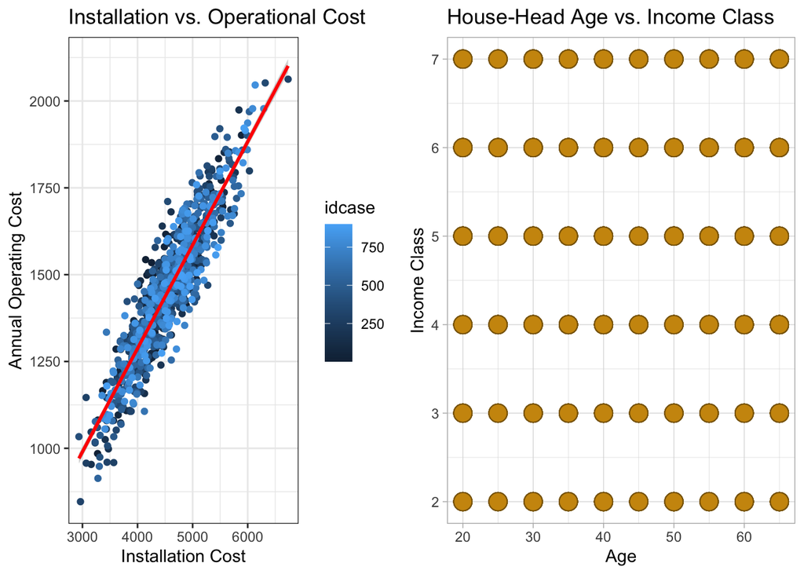

```r
plot1 = ggplot(homeheat, aes(ic.gc + ic.gr + ic.ec + ic.er + ic.hp, oc.gc  + oc.gr  + oc.ec  + oc.er + oc.hp, color = idcase)) +
  geom_point() +
  geom_smooth(method = lm, color = "red") +
  theme_bw() + xlab("Installation Cost") +   ylab("Annual Operating Cost") +
  ggtitle("Installation vs. Operational Cost")

plot2 = ggplot(homeheat, aes(agehed, income)) +
  geom_point(shape = 21, color = "darkgoldenrod4", fill = "darkgoldenrod3", size = 5) +
  theme_light() + xlab("Age") +   ylab("Income Class") +
  ggtitle("House-Head Age vs. Income Class")

library(gridExtra)
grid.arrange(plot1, plot2, ncol = 2)
```